# A simple topic model

Loading packages:

```r
#install.packages("stm")
library("pdftools")
library("quanteda")
library("pdftools")
library("stm")
library("tidyverse")
library("zoo")
```

In this notebook, we will study a topic model estimated on the PDF of Newton’s Principia (1687) which we just downloaded. Reading the book into R with `pdftools` and creating a document frequency matrix with `quanteda`:

```r
principia <- pdf_text("data/Newton_s_Principia.pdf")
```

```
## PDF error: Invalid Font Weight
```

```r
principia <- principia[3:length(principia)]
principia <- str_replace_all(principia, "[\r\n]" , "")
```

```r
principia_dfm <- principia %>% corpus %>%
  tokens(remove_punct = TRUE, remove_numbers = TRUE) %>%
  tokens_remove(stopwords("en"), padding = TRUE) %>%
  tokens_ngrams(n = 1:2) %>% # up to bigrams
  dfm() %>%
  dfm_trim(min_termfreq = 3)
principia_dfm
```

```
## Document-feature matrix of: 609 documents, 7,272 features (98.2% sparse).
##        features
## docs    x ic r o mathematical principles               іі cor therefore another
##   text1 0  0 0 0            0          0                0   0         0       0
##   text2 0  0 0 0            0          0                0   0         0       0
##   text3 0  0 0 0            0          0                0   0         0       0
##   text4 0  0 0 0            0          0                0   0         0       0
##   text5 0  0 0 0            0          0                0   0         0       0
##   text6 1  1 1 1            0          0                0   0         0       0
## [ reached max_ndoc ... 603 more documents, reached max_nfeat ... 7,262 more features ]
```

Note that we only look at one book in this simple example and that we treat each page as a document. Some of these pages will contain very little text. More advanced approaches could combine pages, analyze chapters as documents, or many different books.

Converting the `quanteda` object into an input for the structural topic model:

```r
stm_input <- convert(principia_dfm, to = "stm")
```

In this first example, we will estimate a very simple model with only 3 topics. Note that if we do not supply any covariates, the `stm` package estimates a standard correlated topic model. Hence, we can also use `stm` for general topic modeling without additional covariates. Note that the “spectral” initialization will always return the same model (differences can only result from varying numerical precision on different computers). For other initializations, we could set a pseudo random number seed in order to obtain the same result again, this can be done with the `seed` option in the `stm` function.

```r
ctmodel <- stm(stm_input$documents, stm_input$vocab, K = 3,
               data = stm_input$meta, verbose = FALSE,
               init.type = c("Spectral"))
```

Top words in all topics:

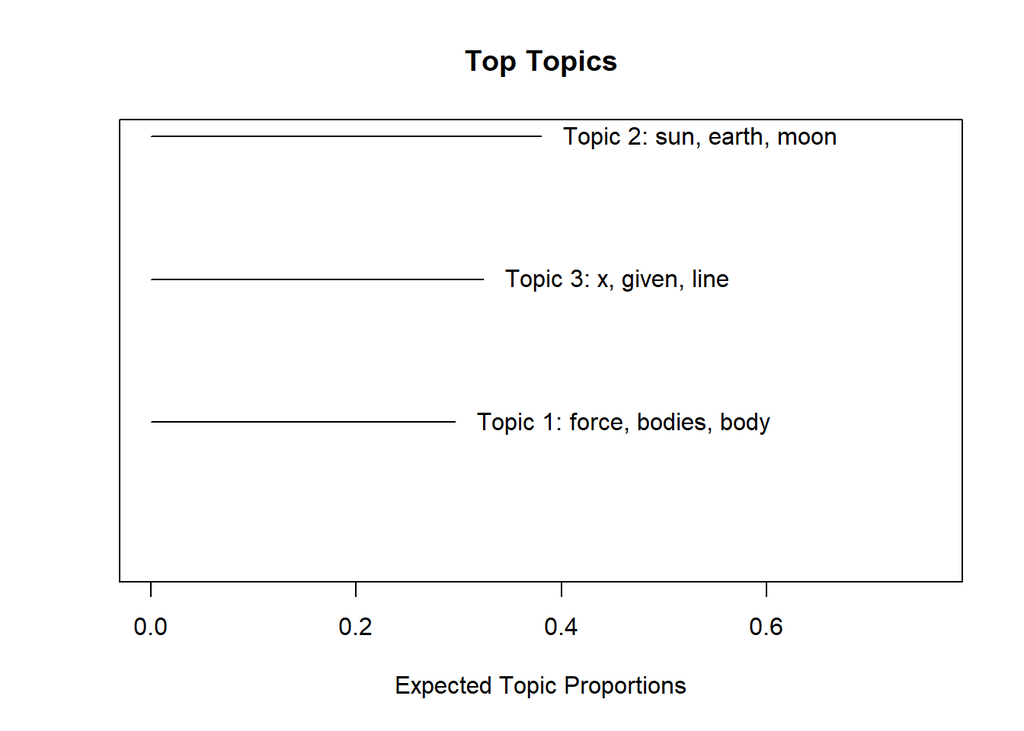

```r
plot(ctmodel)
```

And individual word clouds for each topic:

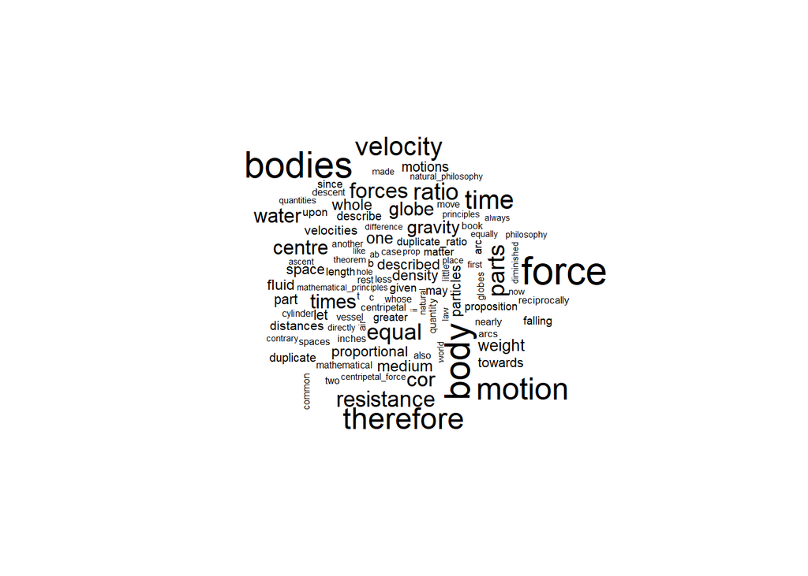

```r
cloud(ctmodel, topic = 1, scale = c(2,.25))
```

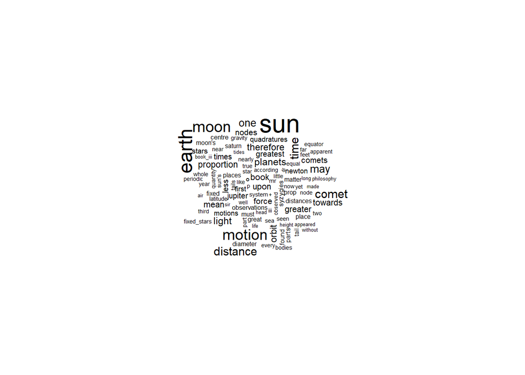

```r
cloud(ctmodel, topic = 2, scale = c(2,.25))
```